# Unit 12 - Tales from the Crypto

## 1. Sentiment Analysis

Use the [newsapi](https://newsapi.org/) to pull the latest news articles for Bitcoin and Ethereum and create a DataFrame of sentiment scores for each coin.

Use descriptive statistics to answer the following questions:

1. Which coin had the highest mean positive score?
2. Which coin had the highest negative score?
3. Which coin had the highest positive score?

```python
import warnings
warnings.simplefilter(action='ignore', category=FutureWarning)
```

```python
# Initial imports
import os
import pandas as pd
from dotenv import load_dotenv
import nltk as nltk
nltk.download('vader_lexicon')
from nltk.sentiment.vader import SentimentIntensityAnalyzer
analyzer = SentimentIntensityAnalyzer()

%matplotlib inline
from newsapi import NewsApiClient
```

```python
# Read your api key environment variable
# YOUR CODE HERE!
# Reading the News API key enviroment variable
load_dotenv()
api_key = os.getenv("news_api")
```

```python
# Create a newsapi client
# YOUR CODE HERE!
# Create a newsapi client
newsapi = NewsApiClient(api_key=api_key)
```

```python
# Fetch the Bitcoin news articles
# YOUR CODE HERE!
btc_news = newsapi.get_everything(
    q="bitcoin",
    language="en",
    page_size=100,
    sort_by="relevancy"
)
```

```python
# Print total articles
print(f"Total articles about Bitcoin: {btc_news['totalResults']}")

# Show sample article
btc_news["articles"][0]
```

```
Total articles about Bitcoin: 7757
```

```
{'source': {'id': 'wired', 'name': 'Wired'},
 'author': 'Khari Johnson',
 'title': 'Why Not Use Self-Driving Cars as Supercomputers?',
 'description': 'Autonomous vehicles use the equivalent of 200 laptops to get around. Some want to tap that computing power to decode viruses or mine bitcoin.',
 'url': 'https://www.wired.com/story/use-self-driving-cars-supercomputers/',
 'urlToImage': 'https://media.wired.com/photos/60f081b4c147fe7a1a367362/191:100/w_1280,c_limit/Business-Autonomous-Vehicles-Supercomputers-1201885684.jpg',
 'publishedAt': '2021-07-19T11:00:00Z',
 'content': 'Like Dogecoin devotees, the mayor of Reno, and the leaders of El Salvador, Aldo Baoicchi is convinced cryptocurrency is the future. The CEO and founder of Canadian scooter maker Daymak believes this … [+4116 chars]'}
```

```python
#btc_news
```

```python
# Fetch the Ethereum news articles
# YOUR CODE HERE!
eth_news = newsapi.get_everything(
    q="ethereum",
    language="en",
    page_size=100,
    sort_by="relevancy"
)
```

```python
# Print total articles
print(f"Total articles about Ethereum: {eth_news['totalResults']}")

# Show sample article
eth_news["articles"][0]
```

```
Total articles about Ethereum: 2310
```

```
{'source': {'id': 'techcrunch', 'name': 'TechCrunch'},
 'author': 'Connie Loizos',
 'title': 'Crypto investors like Terraform Labs so much, they’re committing $150 million to its ‘ecosystem’',
 'description': 'There are many blockchain platforms competing for investors’ and developers’ attention right now, from the big daddy of them all, Ethereum, to so-called “Ethereum Killers” like Solana, which we wrote about in May. Often, these technologies are seen as so prom…',
 'url': 'http://techcrunch.com/2021/07/16/crypto-investors-like-terraform-labs-so-much-theyre-committing-150-million-to-its-ecosystem/',
 'urlToImage': 'https://techcrunch.com/wp-content/uploads/2020/06/GettyImages-1174590894.jpg?w=667',
 'publishedAt': '2021-07-16T16:00:55Z',
 'content': 'There are many blockchain platforms competing for investors’ and developers’ attention right now, from the big daddy of them all, Ethereum, to so-called “Ethereum Killers” like Solana, which we wrote… [+2563 chars]'}
```

```python
eth_news["articles"][0]['description']
```

```
'There are many blockchain platforms competing for investors’ and developers’ attention right now, from the big daddy of them all, Ethereum, to so-called “Ethereum Killers” like Solana, which we wrote about in May. Often, these technologies are seen as so prom…'
```

```python
def create_df(news):
    cnt=0
    articles = []
    for article in news:
        try:
#            title = article["title"]
#            description = article["description"]
            text = article["content"]
            date = article["publishedAt"][:10]
            sentiment = analyzer.polarity_scores(text)
            compound = sentiment["compound"]
            pos = sentiment["pos"]
            neu = sentiment["neu"]
            neg = sentiment["neg"]
            articles.append({
#                "title": title,
#                "description": description,
                "text": text,
                "date": date,
                "compound": compound,
                "positive": pos,
                "negative": neg,
                "neutral": neu
            })
        except AttributeError:
            cnt=cnt+1
            print(cnt)
            pass

    return pd.DataFrame(articles), cnt
```

```python
# Create the Bitcoin sentiment scores DataFrame
# YOUR CODE HERE!
btc_sm_df, c1 = create_df(btc_news["articles"])
# Reorder DataFrame columns
cols = ["date", "text", "compound", "positive", "negative", "neutral"]
btc_sm_df = btc_sm_df[cols]
btc_sm_df.head()
```

|  | date | text | compound | positive | negative | neutral |
| --- | --- | --- | --- | --- | --- | --- |
| 0 | 2021-07-19 | Like Dogecoin devotees, the mayor of Reno, and... | 0.6908 | 0.178 | 0.000 | 0.822 |
| 1 | 2021-07-05 | Filed under:\r\nThe supply chain attack has re... | -0.5719 | 0.111 | 0.184 | 0.705 |
| 2 | 2021-07-05 | image copyrightGetty Images\r\nThe gang behind... | -0.6124 | 0.000 | 0.143 | 0.857 |
| 3 | 2021-07-23 | To get a roundup of TechCrunchs biggest and mo... | 0.6240 | 0.127 | 0.000 | 0.873 |
| 4 | 2021-07-14 | While retail investors grew more comfortable b... | 0.7264 | 0.164 | 0.000 | 0.836 |

```python
len(btc_sm_df)
```

```
100
```

```python
# Create the Ethereum sentiment scores DataFrame
# YOUR CODE HERE!
eth_sm_df, c1 = create_df(eth_news["articles"])
# Reorder DataFrame columns
cols = ["date", "text", "compound", "positive", "negative", "neutral"]
eth_sm_df = eth_sm_df[cols]
eth_sm_df.head()
```

|  | date | text | compound | positive | negative | neutral |
| --- | --- | --- | --- | --- | --- | --- |
| 0 | 2021-07-16 | There are many blockchain platforms competing ... | 0.3612 | 0.075 | 0.000 | 0.925 |
| 1 | 2021-07-14 | While retail investors grew more comfortable b... | 0.7264 | 0.164 | 0.000 | 0.836 |
| 2 | 2021-07-02 | Bitcoin and Ethereum\r\nYuriko Nakao\r\nEther ... | 0.3612 | 0.110 | 0.041 | 0.849 |
| 3 | 2021-07-17 | "Anthony Di Iorio, a co-founder of the Ethereu... | 0.6369 | 0.157 | 0.000 | 0.843 |
| 4 | 2021-07-05 | Ether holders have "staked" more than $13 bill... | 0.7717 | 0.194 | 0.000 | 0.806 |

```python
# Describe the Bitcoin Sentiment
# YOUR CODE HERE!
btc_sm_df.describe()
```

|  | compound | positive | negative | neutral |
| --- | --- | --- | --- | --- |
| count | 100.000000 | 100.000000 | 100.000000 | 100.000000 |
| mean | 0.034312 | 0.043220 | 0.034650 | 0.922110 |
| std | 0.364623 | 0.059131 | 0.059415 | 0.082967 |
| min | -0.827100 | 0.000000 | 0.000000 | 0.653000 |
| 25% | -0.051600 | 0.000000 | 0.000000 | 0.869500 |
| 50% | 0.000000 | 0.000000 | 0.000000 | 0.929500 |
| 75% | 0.272000 | 0.079250 | 0.065000 | 1.000000 |
| max | 0.865800 | 0.276000 | 0.287000 | 1.000000 |

```python
# Describe the Ethereum Sentiment
# YOUR CODE HERE!
eth_sm_df.describe()
```

|  | compound | positive | negative | neutral |
| --- | --- | --- | --- | --- |
| count | 100.000000 | 100.000000 | 100.00000 | 100.000000 |
| mean | 0.149017 | 0.053640 | 0.02201 | 0.924360 |
| std | 0.340847 | 0.059701 | 0.04329 | 0.070166 |
| min | -0.812600 | 0.000000 | 0.00000 | 0.714000 |
| 25% | 0.000000 | 0.000000 | 0.00000 | 0.864250 |
| 50% | 0.000000 | 0.042000 | 0.00000 | 0.928000 |
| 75% | 0.461050 | 0.094750 | 0.04125 | 1.000000 |
| max | 0.771700 | 0.194000 | 0.24900 | 1.000000 |

### Questions:

Q: Which coin had the highest mean positive score?

A: Ethereuam has higher mean positive scrore 0.053640 vs Bitcoin 0.043220

Q: Which coin had the highest compound score?

A: Bitcoin has highest compound score 0.865800 - vs Ethereum 0.771700

Q. Which coin had the highest positive score?

A: Bitcoin has highest positive score 0.276000 vs Ethereum 0.194000

## 2. Natural Language Processing

### Tokenizer

In this section, you will use NLTK and Python to tokenize the text for each coin. Be sure to:

1. Lowercase each word.
2. Remove Punctuation.
3. Remove Stopwords.

```python
from nltk.tokenize import word_tokenize, sent_tokenize
from nltk.corpus import stopwords
from nltk.stem import WordNetLemmatizer, PorterStemmer
from string import punctuation
import re
```

```python
# Code to download
import nltk
nltk.download('stopwords')
```

```
True
```

```python
# Instantiate the lemmatizer
# YOUR CODE HERE!
lemmatizer = WordNetLemmatizer()
# Create a list of stopwords
# YOUR CODE HERE!
sw = set(stopwords.words('english'))
print(sw)
# Expand the default stopwords list if necessary
# YOUR CODE HERE!
sw.add('tldr')
```

```
{'it', "wouldn't", 'hers', 'than', "you'll", 'very', 'i', 'hasn', 'off', 'y', 'you', 'couldn', 'haven', 'ourselves', "hasn't", 'under', 'ma', 'has', 'how', 'of', 's', 'by', 'few', 'won', 'more', "should've", 'below', 'were', 'this', 'why', 'only', 'there', 'm', 'up', 'does', 'after', 'don', 'at', 'a…
```

```python
type(sw)
```

```
set
```

```python
el_in_set = 'tldr' in sw
print(el_in_set)
```

```
True
```

#### test removing punctuations

```python
text1 = 'class starts at 630!! Hello!!!, he said ---and went.'
sw = set(stopwords.words('english'))
regex = re.compile("[^a-zA-Z0-9 ]")
re_clean1 = regex.sub('', text1)
re_clean1
```

```
'class starts at 630 Hello he said and went'
```

```python
# Complete the tokenizer function
def tokenizer(text):
    """Tokenizes text."""

    # Remove the punctuation from text
    regex = re.compile("[^a-zA-Z0-9 ]")
    re_clean = regex.sub('', text)

    # Create a tokenized list of the words
    words = word_tokenize(re_clean)

    # Lemmatize words into root words
    lem = [lemmatizer.lemmatize(word) for word in words]

    # Convert the words to lowercase


    # Remove the stop words
    tokens = [word.lower() for word in lem if word.lower() not in sw]

    return tokens
```

```python
btc_sm_df['text']
```

```
0     Like Dogecoin devotees, the mayor of Reno, and...
1     Filed under:\r\nThe supply chain attack has re...
2     image copyrightGetty Images\r\nThe gang behind...
3     To get a roundup of TechCrunchs biggest and mo...
4     While retail investors grew more comfortable b...
5     As longtime TechCrunch readers know well, Mich...
6     LONDON, June 23 (Reuters) - El Salvador is det...
7     LONDON, June 23 (Reuters) - El Salvador is det...
8     A representation of virtual currency Bitcoin i...
9     A representation of the virtual cryptocurrency...
10    By Reuters Staff\r\nFILE PHOTO: Representation...
11    James Martin/CNET\r\nA UK man was arrested in ...
12    By Reuters Staff\r\nJune 25 (Reuters) - Bitcoi...
13    A representations of virtual currency Bitcoin ...
14    By Reuters Staff\r\nJune 25 (Reuters) - Bitcoi...
```

[output cut: 47 more lines]

```python
# Create a new tokens column for Bitcoin
# YOUR CODE HERE!
#btc_sm_df['tokens'] = tokenizer(btc_sm_df['text'])
tokens_btc = []
for index, row in btc_sm_df.iterrows():
    tokens = tokenizer(row['text'])
#    print('***')
#    print(tokens)
    tokens_btc.append(tokens)
```

```python
len(tokens_btc)
```

```
100
```

```python
btc_sm_df['tokens'] = tokens_btc
```

```python
pd.set_option('display.max_colwidth', -1)
btc_sm_df.head()
```

|  | date | text | compound | positive | negative | neutral | tokens |
| --- | --- | --- | --- | --- | --- | --- | --- |
| 0 | 2021-07-19 | Like Dogecoin devotees, the mayor of Reno, and the leaders of El Salvador, Aldo Baoicchi is convinced cryptocurrency is the future. The CEO and founder of Canadian scooter maker Daymak believes this …… | 0.6908 | 0.178 | 0.000 | 0.822 | [like, dogecoin, devotee, mayor, reno, leader, el, salvador, aldo, baoicchi, convinced, cryptocurrency, future, ceo, founder, canadian, scooter, maker, daymak, belief, 4116, char] |
| 1 | 2021-07-05 | Filed under:\r\nThe supply chain attack has reached over a thousand organizations.\r\nIllustration by Alex Castro / The Verge\r\nThree days after ransomware attackers started the holiday weekend by co… | -0.5719 | 0.111 | 0.184 | 0.705 | [filed, underthe, supply, chain, attack, ha, reached, thousand, organizationsillustration, alex, castro, vergethree, day, ransomware, attacker, started, holiday, weekend, comprom, 3376, char] |
| 2 | 2021-07-05 | image copyrightGetty Images\r\nThe gang behind a "colossal" ransomware attack has demanded $70m (£50.5m) paid in Bitcoin in return for a "universal decryptor" that it says will unlock the files of all… | -0.6124 | 0.000 | 0.143 | 0.857 | [image, copyrightgetty, imagesthe, gang, behind, colossal, ransomware, attack, ha, demanded, 70m, 505m, paid, bitcoin, return, universal, decryptor, say, unlock, file, 4140, char] |
| 3 | 2021-07-23 | To get a roundup of TechCrunchs biggest and most important stories delivered to your inbox every day at 3 p.m. PDT, subscribe here.\r\nHello and welcome to Daily Crunch for July 23, 2021. Its been an … | 0.6240 | 0.127 | 0.000 | 0.873 | [get, roundup, techcrunchs, biggest, important, story, delivered, inbox, every, day, 3, pm, pdt, subscribe, herehello, welcome, daily, crunch, july, 23, 2021, 5456, char] |
| 4 | 2021-07-14 | While retail investors grew more comfortable buying cryptocurrencies like Bitcoin and Ethereum in 2021, the decentralized application world still has a lot of work to do when it comes to onboarding a…… | 0.7264 | 0.164 | 0.000 | 0.836 | [retail, investor, grew, comfortable, buying, cryptocurrencies, like, bitcoin, ethereum, 2021, decentralized, application, world, still, ha, lot, work, come, onboarding, 2288, char] |

```python
# Create a new tokens column for Ethereum
# YOUR CODE HERE!
tokens_eth = []
for index, row in eth_sm_df.iterrows():
    tokens = tokenizer(row['text'])
#    print('***')
#    print(tokens)
    tokens_eth.append(tokens)
```

```python
eth_sm_df['tokens'] = tokens_eth
```

```python
eth_sm_df.head()
```

|  | date | text | compound | positive | negative | neutral | tokens |
| --- | --- | --- | --- | --- | --- | --- | --- |
| 0 | 2021-07-16 | There are many blockchain platforms competing for investors’ and developers’ attention right now, from the big daddy of them all, Ethereum, to so-called “Ethereum Killers” like Solana, which we wrote…… | 0.3612 | 0.075 | 0.000 | 0.925 | [many, blockchain, platform, competing, investor, developer, attention, right, big, daddy, ethereum, socalled, ethereum, killers, like, solana, wrote, 2563, char] |
| 1 | 2021-07-14 | While retail investors grew more comfortable buying cryptocurrencies like Bitcoin and Ethereum in 2021, the decentralized application world still has a lot of work to do when it comes to onboarding a…… | 0.7264 | 0.164 | 0.000 | 0.836 | [retail, investor, grew, comfortable, buying, cryptocurrencies, like, bitcoin, ethereum, 2021, decentralized, application, world, still, ha, lot, work, come, onboarding, 2288, char] |
| 2 | 2021-07-02 | Bitcoin and Ethereum\r\nYuriko Nakao\r\nEther overtook bitcoin in the number of active addresses on its network on Friday, a sign that demand is faltering for the world's biggest cryptocurrency as its… | 0.3612 | 0.110 | 0.041 | 0.849 | [bitcoin, ethereumyuriko, nakaoether, overtook, bitcoin, number, active, address, network, friday, sign, demand, faltering, world, biggest, cryptocurrency, co, 2727, char] |
| 3 | 2021-07-17 | "Anthony Di Iorio, a co-founder of the Ethereum network, says he's done with the cryptocurrency world, partially because of personal safety concerns," reports Bloomberg, in a story shared by Slashdot…… | 0.6369 | 0.157 | 0.000 | 0.843 | [anthony, di, iorio, cofounder, ethereum, network, say, done, cryptocurrency, world, partially, personal, safety, concern, report, bloomberg, story, shared, slashdot, 1550, char] |
| 4 | 2021-07-05 | Ether holders have "staked" more than $13 billion worth of the cryptocurrency on the ethereum 2.0 network, as excitement builds around the overhaul of the system and the potential growth of the staki…… | 0.7717 | 0.194 | 0.000 | 0.806 | [ether, holder, staked, 13, billion, worth, cryptocurrency, ethereum, 20, network, excitement, build, around, overhaul, system, potential, growth, staki, 1851, char] |

```python
btc_sm_df['text'][0]
```

```
'Like Dogecoin devotees, the mayor of Reno, and the leaders of El Salvador, Aldo Baoicchi is convinced cryptocurrency is the future. The CEO and founder of Canadian scooter maker Daymak believes this … [+4116 chars]'
```

```python
tokens_btc[0]
```

```
['like',
 'dogecoin',
 'devotee',
 'mayor',
 'reno',
 'leader',
 'el',
 'salvador',
 'aldo',
 'baoicchi',
 'convinced',
 'cryptocurrency',
 'future',
 'ceo',
 'founder',
 'canadian',
 'scooter',
 'maker',
 'daymak',
 'belief',
 '4116',
 'char']
```

```python
eth_sm_df['text'][0]
```

```
'There are many blockchain platforms competing for investors’ and developers’ attention right now, from the big daddy of them all, Ethereum, to so-called “Ethereum Killers” like Solana, which we wrote… [+2563 chars]'
```

```python
tokens_eth[0]
```

```
['many',
 'blockchain',
 'platform',
 'competing',
 'investor',
 'developer',
 'attention',
 'right',
 'big',
 'daddy',
 'ethereum',
 'socalled',
 'ethereum',
 'killers',
 'like',
 'solana',
 'wrote',
 '2563',
 'char']
```

### NGrams and Frequency Analysis

In this section you will look at the ngrams and word frequency for each coin.

1. Use NLTK to produce the n-grams for N = 2.
2. List the top 10 words for each coin.

```python
from collections import Counter
from nltk import ngrams
```

```python
type(tokens_btc)
```

```
list
```

```python
len(tokens_btc)
```

```
100
```

```python
from pandas.core.common import flatten
tokens_btc_flat = list(flatten(tokens_btc))
```

```python
# Generate the Bitcoin N-grams where N=2
# YOUR CODE HERE!
btc_bigram_counts = Counter(ngrams(tokens_btc_flat, n=2))
print(dict(btc_bigram_counts))
```

```
{('like', 'dogecoin'): 1, ('dogecoin', 'devotee'): 1, ('devotee', 'mayor'): 1, ('mayor', 'reno'): 1, ('reno', 'leader'): 1, ('leader', 'el'): 1, ('el', 'salvador'): 9, ('salvador', 'aldo'): 1, ('aldo', 'baoicchi'): 1, ('baoicchi', 'convinced'): 1, ('convinced', 'cryptocurrency'): 1, ('cryptocurrency…
```

```python
# Generate the Ethereum N-grams where N=2
# YOUR CODE HERE!
tokens_eth_flat = list(flatten(tokens_eth))
eth_bigram_counts = Counter(ngrams(tokens_eth_flat, n=2))
print(eth_bigram_counts)
```

```
Counter({('taken', 'june'): 17, ('illustration', 'taken'): 17, ('2021', 'reutersdado'): 14, ('bitcoin', 'ethereum'): 13, ('cryptocurrencies', 'bitcoin'): 11, ('ethereum', 'dogecoin'): 11, ('char', 'representations'): 11, ('nonfungible', 'token'): 10, ('representations', 'cryptocurrencies'): 10, ('do…
```

```python
# Function token_count generates the top 10 words for a given coin
def token_count(tokens, N=3):
    """Returns the top N tokens from the frequency count"""
    return Counter(tokens).most_common(N)
```

```python
# Use token_count to get the top 10 words for Bitcoin
# YOUR CODE HERE!
top10_btc = token_count(tokens_btc_flat, 10)
print(top10_btc)
```

```
[('char', 95), ('bitcoin', 77), ('reuters', 49), ('june', 32), ('cryptocurrency', 23), ('2021', 23), ('illustration', 23), ('seen', 20), ('taken', 20), ('july', 18)]
```

```python
# Use token_count to get the top 10 words for Ethereum
# YOUR CODE HERE!
top10_eth = token_count(tokens_eth_flat, 10)
print(top10_eth)
```

```
[('char', 99), ('bitcoin', 39), ('ethereum', 33), ('cryptocurrency', 28), ('2021', 25), ('cryptocurrencies', 24), ('june', 24), ('illustration', 21), ('reuters', 20), ('taken', 19)]
```

### Word Clouds

In this section, you will generate word clouds for each coin to summarize the news for each coin

```python
from wordcloud import WordCloud
import matplotlib.pyplot as plt
plt.style.use('seaborn-whitegrid')
import matplotlib as mpl
mpl.rcParams['figure.figsize'] = [20.0, 10.0]
```

```python
def listToString(s):
    # initialize an empty string
    str1 = " "
    # return string
    return (str1.join(s))
```

```python
btc_string = listToString(tokens_btc_flat)
```

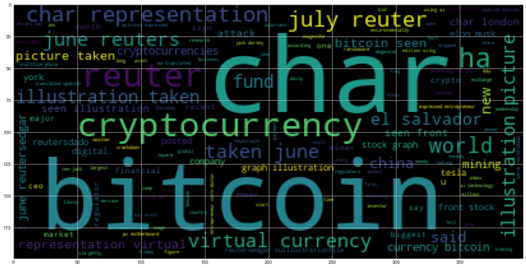

```python
# Generate the Bitcoin word cloud
# YOUR CODE HERE!
wc = WordCloud().generate(btc_string)
plt.imshow(wc)
```

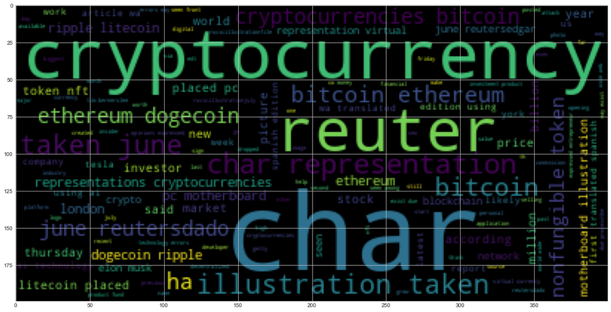

```python
# Generate the Ethereum word cloud
# YOUR CODE HERE!
eth_string = listToString(tokens_eth_flat)
wc = WordCloud().generate(eth_string)
plt.imshow(wc)
```

## 3. Named Entity Recognition

In this section, you will build a named entity recognition model for both Bitcoin and Ethereum, then visualize the tags using SpaCy.

```python
import spacy
from spacy import displacy
```

```python
# Download the language model for SpaCy
# !python -m spacy download en_core_web_sm
```

```python
# Load the spaCy model
nlp = spacy.load('en_core_web_sm')
```

### Bitcoin NER

```python
btc_text = ' '.join(btc_sm_df['text'])
eth_text = ' '.join(eth_sm_df['text'])
```

```python
# Concatenate all of the Bitcoin text together
# YOUR CODE HERE!
#btc_string
btc_text
```

```
'Like Dogecoin devotees, the mayor of Reno, and the leaders of El Salvador, Aldo Baoicchi is convinced cryptocurrency is the future. The CEO and founder of Canadian scooter maker Daymak believes this … [+4116 chars] Filed under:\r\nThe supply chain attack has reached over a thousand organizations.\r…
```

```python
type(btc_string)
```

```
str
```

```python
# Run the NER processor on all of the text
# YOUR CODE HERE!
doc = nlp(btc_text)
# Add a title to the document
# YOUR CODE HERE!
doc.user_data["title"] = "Bitcoin NER"
```

```python
!conda list spacy
```

```
# packages in environment at C:\Users\chakravartiraghavan\anaconda3\envs\nlpenv:
#
# Name                    Version                   Build  Channel
spacy                     3.0.5            py37h3b38789_0    conda-forge
spacy-legacy              3.0.6              pyhd8ed1ab_0    conda-forge
```

### there is also Spacy latest version 3.1 so maybe that might have some better Name Entity Recognition

```python
# Render the visualization
# YOUR CODE HERE!
displacy.render(doc, style='ent')
```

Bitcoin NER

Like Dogecoin PERSON devotees, the mayor of Reno PERSON , and the leaders of El Salvador GPE , Aldo Baoicchi GPE is convinced cryptocurrency is the future. The CEO and founder of Canadian NORP scooter maker Daymak ORG believes this … [+4116 chars] Filed under:  
The supply chain attack has reached over a thousand organizations.  
Illustration by Alex Castro PERSON / The Verge ORG  
Three days DATE after ransomware attackers started the holiday weekend DATE by comprom… [+3376 chars] image copyrightGetty Images  
The gang behind a "colossal" ransomware attack has demanded $70m MONEY ( £50.5m MONEY ) paid in Bitcoin PERSON in return for a "universal decryptor" that it says will unlock the files of all … [+4140 chars] To get a roundup of TechCrunchs biggest and most important stories delivered to your inbox every day at 3 p.m. PDT TIME , subscribe here.  
Hello and welcome to Daily Crunch WORK_OF_ART for July 23, 2021 DATE . Its been an i… [+5456 chars] While retail investors grew more comfortable buying cryptocurrencies like Bitcoin and Ethereum ORG in 2021 DATE , the decentralized application world still has a lot of work to do when it comes to onboarding a… [+2288 chars] As longtime TechCrunch ORG readers know well, Michael Arrington PERSON cofounded TechCrunch and Crunchbase ORG , as well as the venture fund CrunchFund ORG , which was later renamed Tuesday DATE Capital. But In 2017 DATE , Arringto… [+12730 chars] LONDON GPE , June 23 DATE ( Reuters ORG ) - El Salvador GPE is determined to push ahead with making bitcoin legal tender, a process that will bring only small risks and prove a "leap forward for humanity", the country's… [+2764 chars] LONDON GPE , June 23 DATE ( Reuters ORG ) - El Salvador GPE is determined to push ahead with making bitcoin legal tender, a process that will bring only small risks and prove a leap forward for humanity, the countrys Pr PERSON … [+2648 chars] A representation of virtual currency Bitcoin PERSON is seen in front of a stock graph in this illustration taken March 15, 2021 DATE . REUTERS/ Dado Ruvic PERSON /IllustrationLONDON, June 30 DATE ( Reuters ORG ) - If you're a bitcoi… [+3630 chars] A representation of the virtual cryptocurrency Bitcoin PERSON is seen in this picture illustration taken June 14, 2021 DATE . REUTERS/ Edgar Su PERSON /IllustrationJune 25 ( Reuters ORG ) - Bitcoin dropped 7.37% PERCENT to $ 32,094.44 MONEY o… [+434 chars] By Reuters ORG Staff  
FILE PHOTO: Representations of the Bitcoin ORG cryptocurrency are seen in this illustration picture taken June 7, 2021 DATE . REUTERS/ Edgar Su/Illustration/File Photo PERSON ( Reuters ORG ) - Bitcoin ros… [+304 chars] James Martin PERSON / CNET ORG  
A UK GPE man was arrested in Spain GPE for his alleged role in a massive hack of high-profile Twitter PRODUCT accounts that targeted politicians and celebrities in 2020 DATE , the US Department of Justi ORG … [+1397 chars] By Reuters ORG Staff  
June 25 DATE ( Reuters ORG ) - Bitcoin dropped 7.37% PERCENT to $ 32,094.44…

```python
# List all Entities
# YOUR CODE HERE!
#print([ent.text for ent in doc.ents])
for ent in doc.ents:
    print(ent.text, ent.label_)
```

```
Dogecoin PERSON
Reno PERSON
El Salvador GPE
Aldo Baoicchi GPE
Canadian NORP
Daymak ORG
Alex Castro PERSON
Verge ORG
Three days DATE
the holiday weekend DATE
$70m MONEY
£50.5m MONEY
Bitcoin PERSON
3 p.m. PDT TIME
Daily Crunch WORK_OF_ART
July 23, 2021 DATE
Bitcoin and Ethereum ORG
2021 DATE
TechCrunch ORG
Michael Arrington PERSON
Crunchbase ORG
CrunchFund ORG
Tuesday DATE
2017 DATE
LONDON GPE
June 23 DATE
Reuters ORG
El Salvador GPE
LONDON GPE
June 23 DATE
Reuters ORG
El Salvador GPE
Pr PERSON
Bitcoin PERSON
March 15, 2021 DATE
Dado Ruvic PERSON
June 30 DATE
Reuters ORG
Bitcoin PERSON
June 14, 2021 DATE
```

[output cut: 398 more lines]

```
Getty
 ORG
500,000 MONEY
three years DATE
NEW YORK GPE
July 1 DATE
Reuters ORG
Japan GPE
SoftBank Group Corp ORG
9984.T CARDINAL
$200 million MONEY
Mercado Bitcoin PERSON
one CARDINAL
Latin America LOC
Roberto Dagnoni PERSON
```

### Ethereum NER

```python
# Concatenate all of the Ethereum text together
# YOUR CODE HERE!
```

```python
# Run the NER processor on all of the text
# YOUR CODE HERE!

# Add a title to the document
# YOUR CODE HERE!

doc1 = nlp(eth_text)
# Add a title to the document
# YOUR CODE HERE!
doc1.user_data["title"] = "Ethereum NER"
```

```python
# Render the visualization
# YOUR CODE HERE!
displacy.render(doc1, style='ent')
```

Ethereum NER

There are many blockchain platforms competing for investors’ and developers’ attention right now, from the big daddy of them all, Ethereum ORG , to so-called “ Ethereum Killers WORK_OF_ART ” like Solana PERSON , which we wrote… [+2563 chars] While retail investors grew more comfortable buying cryptocurrencies like Bitcoin and Ethereum ORG in 2021 DATE , the decentralized application world still has a lot of work to do when it comes to onboarding a… [+2288 chars] Bitcoin and Ethereum  
Yuriko Nakao PERSON  
Ether overtook bitcoin in the number of active addresses on its network on Friday DATE , a sign that demand is faltering for the world's biggest cryptocurrency as its co… [+2727 chars] " Anthony Di Iorio PERSON , a co-founder of the Ethereum ORG network, says he's done with the cryptocurrency world, partially because of personal safety concerns," reports Bloomberg PERSON , in a story shared by Slashdot ORG … [+1550 chars] Ether holders have "staked" more than $13 billion MONEY worth of the cryptocurrency on the ethereum 2.0 CARDINAL network, as excitement builds around the overhaul of the system and the potential growth of the staki… [+1851 chars] Ether is the cryptocurrency of the ethereum network.  
Photothek/Getty Images PERSON  
Ether holders have "staked" more than $13 billion MONEY worth of the cryptocurrency on the ethereum 2.0 CARDINAL network, as excitement … [+1935 chars] Major upgrades to the ethereum network could help turn crypto staking into a $40 billion MONEY business by 2025 DATE , according to analysts at JPMorgan ORG .  
The staking industry in which users earn cryptocurrency … [+2320 chars] You’ve likely seen the headlines surrounding the pretty major decline in NFT ORG sales from the market’s recent peak, with some reports indicating as much as CARDINAL a 90 percent PERCENT decline in recent weeks DATE . And whi… [+2025 chars] While the ambitions of crypto investors have swelled even faster than the market has in recent months DATE , institutional players have had a mountain of blockchain data to try to make sense of without par… [+2313 chars] Personal Finance Insider writes about products, strategies, and tips to help you make smart decisions with your money. We may receive a small commission from our partners, like American Express ORG , but … [+5827 chars] This article was translated from our Spanish NORP edition using AI ORG technologies. Errors may exist due to this process.  
The Securities and Exchange Commission ORG (CVM), the body that regulates securities in … [+1015 chars] By Reuters ORG Staff  
June 25 DATE ( Reuters ORG ) - Bitcoin dropped 7.37% PERCENT to $ 32,094.44 MONEY on Friday DATE , losing $ 2,554.88 MONEY from its previous close.  
Bitcoin PERSON , the worlds biggest and best-known cryptocurrency, is down 50.5 CARDINAL … [+253 chars] By Reuters ORG Staff  
June 25 DATE ( Reuters ORG ) - Bitcoin dipped 8.51% PERCENT to $ 31,699.83 MONEY at 22:04 CARDINAL GMT ORG on Friday DATE , losing $ 2,937.27 MONEY from its previous …

```python
# List all Entities
# YOUR CODE HERE!
for ent in doc1.ents:
    print(ent.text, ent.label_)
```

```
Ethereum ORG
Ethereum Killers WORK_OF_ART
Solana PERSON
Bitcoin and Ethereum ORG
2021 DATE
Yuriko Nakao PERSON
Friday DATE
Anthony Di Iorio PERSON
Ethereum ORG
Bloomberg PERSON
Slashdot ORG
more than $13 billion MONEY
2.0 CARDINAL
Photothek/Getty Images PERSON
more than $13 billion MONEY
2.0 CARDINAL
$40 billion MONEY
2025 DATE
JPMorgan ORG
NFT ORG
as much as CARDINAL
90 percent PERCENT
recent weeks DATE
recent months DATE
American Express ORG
Spanish NORP
AI ORG
The Securities and Exchange Commission ORG
Reuters ORG
June 25 DATE
Reuters ORG
7.37% PERCENT
32,094.44 MONEY
Friday DATE
2,554.88 MONEY
Bitcoin PERSON
50.5 CARDINAL
Reuters ORG
June 25 DATE
Reuters ORG
```

[output cut: 345 more lines]

```
thousands CARDINAL
English LANGUAGE
Damien Hirst’s PERSON
two CARDINAL
Wednesday DATE
Elon Musk PERSON
the Crypto Council for Inno ORG
Betterment GPE
U.S. GPE
6.4% PERCENT
annual DATE
the first quarter DATE
the Commerce Department ORG
Thursday DATE
JPMorgan ORG
```